# Analyzing the Local Law 97 of 2021-Pets in Shelter Report

Xinru Wang

```r
knitr::opts_chunk$set(warning = FALSE, message = FALSE)
library(nycOpenData)
library(ggplot2)
library(dplyr)
```

## Introduction

New York City serves a large and diverse population, including individuals and families who experience housing instability and may rely on homeless shelters for temporary support. Pets serve many important role in people’s lives, and understanding pet ownership among shelter entrants helps inform shelter policy, access to services, and resource planning.

The **Local Law 97 of 2021 – Pets in Shelter Report** provides quarterly survey data on the types of pets owned by people entering New York City homeless shelters.This dataset was recently added to NYC Open Data and made publicly available on October 14, 2025. These data are published through NYC Open Data and are available [here](https://data.cityofnewyork.us/Social-Services/Local-Law-97-of-2021-Pets-in-Shelter-Report/5nux-zfmw/about_data).

The `nycOpenData` package provides a streamlined interface for accessing New York City’s open data resources directly in R. By using the `nyc_locallaw97_shelter_pets()` function, we can retrieve the most recent quarterly shelter pet data and explore trends in pet ownership across time using familiar data analysis tools.

## Pulling a Small Sample

To start, we’ll pull a small sample of the data to get a sense of what it looks like. By default, the function retrieves the 10,000 most recent requests, so we’ll adjust this and only load the latest 3 by using `limit = 3`.

```r
small_sample <- nyc_locallaw97_shelter_pets(limit = 3)
small_sample
```

```
#> # A tibble: 3 × 24
#>   date_year date_quarter total_applicants had_pet client_borough_of_entry_bronx
#>   <chr>     <chr>        <chr>            <chr>   <chr>
#> 1 2026      Qtr 1        12062            16      16
#> 2 2025      Qtr 4        12727            10      10
#> 3 2025      Qtr 3        11704            10      10
#> # ℹ 19 more variables: client_borough_of_entry <chr>,
#> #   client_borough_of_entry_1 <chr>, clients_who_would_have_entered <chr>,
#> #   clients_choosing_to_forego <chr>, chose_to_forego_shelter_for <chr>,
#> #   clients_who_intend_to_regain <chr>, number_of_dogs <chr>,
#> #   number_of_cats <chr>, number_of_birds <chr>, number_of_small_mammals <chr>,
#> #   number_of_reptiles_small <chr>, number_of_fish <chr>,
#> #   did_not_report_pet_type <chr>, pet_s_placed_with_foster <chr>, …
```

```r
# Seeing what columns are in the dataset
colnames(small_sample)
```

```
#>  [1] "date_year"                      "date_quarter"
#>  [3] "total_applicants"               "had_pet"
#>  [5] "client_borough_of_entry_bronx"  "client_borough_of_entry"
#>  [7] "client_borough_of_entry_1"      "clients_who_would_have_entered"
#>  [9] "clients_choosing_to_forego"     "chose_to_forego_shelter_for"
#> [11] "clients_who_intend_to_regain"   "number_of_dogs"
#> [13] "number_of_cats"                 "number_of_birds"
#> [15] "number_of_small_mammals"        "number_of_reptiles_small"
#> [17] "number_of_fish"                 "did_not_report_pet_type"
#> [19] "pet_s_placed_with_foster"       "pet_s_surrendered_to_animal"
#> [21] "pet_s_placed_with_family"       "pet_s_placed_with_friend"
#> [23] "pet_s_placed_with_other"        "pet_s_placed_with_non_profit"
```

Fantastic! We successfully pulled the `Local Law 97 of 2021-Pets in Shelter Report` data from the NYC Open Data Portal using the `nyc_locallaw97_shelter_pets()` function.

```r
recent_quarters <- nyc_locallaw97_shelter_pets(
  limit = 3,
  filters = list(date_year = 2024))

recent_quarters
```

```
#> # A tibble: 3 × 24
#>   date_year date_quarter total_applicants had_pet client_borough_of_entry_bronx
#>   <chr>     <chr>        <chr>            <chr>   <chr>
#> 1 2024      Qtr 4        11874            4       4
#> 2 2024      Qtr 3        11901            2       2
#> 3 2024      Qtr 2        12274            4       4
#> # ℹ 19 more variables: client_borough_of_entry <chr>,
#> #   client_borough_of_entry_1 <chr>, clients_who_would_have_entered <chr>,
#> #   clients_choosing_to_forego <chr>, chose_to_forego_shelter_for <chr>,
#> #   clients_who_intend_to_regain <chr>, number_of_dogs <chr>,
#> #   number_of_cats <chr>, number_of_birds <chr>, number_of_small_mammals <chr>,
#> #   number_of_reptiles_small <chr>, number_of_fish <chr>,
#> #   did_not_report_pet_type <chr>, pet_s_placed_with_foster <chr>, …
```

```r
# Checking to see the filtering worked
unique(recent_quarters$date_year)
```

```
#> [1] "2024"
```

Success! From calling the filtered dataset, we see that only three rows of data are returned, and the `unique()` check confirms that all observations come from the specified year.

```r
# Creating the dataset
pets_filtered <- nyc_locallaw97_shelter_pets(
  limit = 20,
  filters = list(
    date_year = 2024,
    had_pet = 1))

# Calling head of our new dataset
head(pets_filtered)
```

```
#> # A tibble: 0 × 0
```

```r
# Quick check to make sure our filtering worked
nrow(pets_filtered)
```

```
#> [1] 0
```

```r
unique(pets_filtered$date_year)
```

[output not shown]

```r
unique(pets_filtered$had_pet)
```

[output not shown]

## Mini analysis

Now that we’ve successfully pulled the data and have it in R, let’s do a quick mini analysis to look at how the number of shelter entrants who reported having pets changes over time.

To do this, we’ll create a simple bar chart showing the number of applicants with pets in each year.

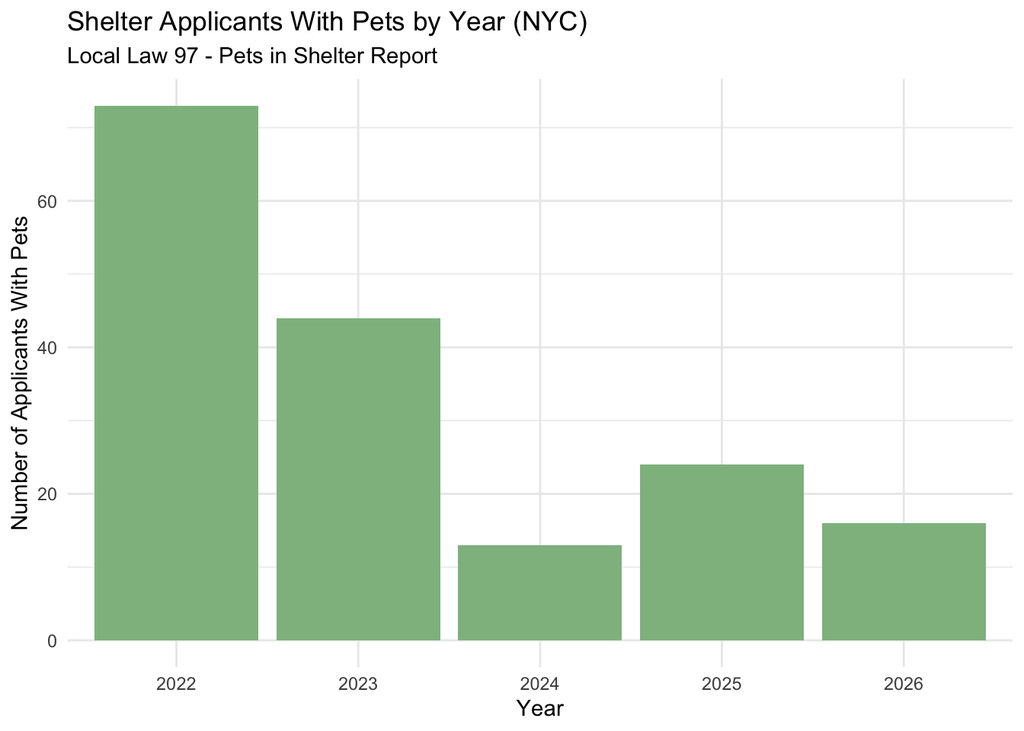

Bar chart showing the number of shelter applicants with pets by year.

```r
pets <- nyc_locallaw97_shelter_pets(limit = 100)
pets$had_pet <- as.numeric(pets$had_pet)

# Summarize by year
pet_by_year <- pets %>%
  group_by(date_year) %>%
  summarize(applicants_with_pets = sum(had_pet, na.rm = TRUE))

# Plot
ggplot(pet_by_year, aes(x = date_year, y = applicants_with_pets)) +
  geom_col(fill = "darkseagreen") +
  theme_minimal() +
  labs(
    title = "Shelter Applicants With Pets by Year (NYC)",
    subtitle = "Local Law 97 - Pets in Shelter Report",
    x = "Year",
    y = "Number of Applicants With Pets"
  )
```

This graph shows how the number of shelter entrants reporting pets changes across years, which can help highlight broader trends and guide planning for pet-related shelter resources.

## Summary

The `nycOpenData` package serves as a robust interface for the NYC Open Data portal, streamlining the path from raw city APIs to actionable insights. By abstracting the complexities of data acquisition—such as pagination, type-casting, and complex filtering—it allows users to focus on analysis rather than data engineering.

As demonstrated in this vignette, the package provides a seamless workflow for targeted data retrieval, automated filtering, and rapid visualization.

## How to Cite

If you use this package for research or educational purposes, please cite it as follows:

Martinez C (2026). nycOpenData: Convenient Access to NYC Open Data API Endpoints. R package version 0.1.6, https://martinezc1.github.io/nycOpenData/.